# Predicting Adverse Outcomes for Debt Consolidation Loans

## Introduction

Lending Club is a peer-to-peer lending platform based in the U.S. On their website, they regularly publish datasets that include attributes about the customer and loan that are collected at the time of application or during the debt repayment window.

These datasets are quite popular among Kaggle competitors and other data science enthusiasts. For additional information about Lending Club, visit any of the links below.

- Wiki: https://en.wikipedia.org/wiki/Lending_Club
- Website: https://www.lendingclub.com
- Datasets: https://www.lendingclub.com/info/download-data.action

In this report, we share the results of a modeling exercise in which we attempt to predict adverse outcomes for Lending Club loans to be used for debt consolidation purposes. The dataset used for this exercise are related to loan applications processed in **2016, Quarter 2**.  
Report updated 2018-11-09 14:43:13.

## Dataset

The 2016 Q2 dataset consisted of 97858 records. Selected Lending Club attributes were joined to state-level population summaries to produce the modeling dataset. For the analysis, we focused on the 54783 loans for debt consolidation. Late payment, default, or charge-off loan statuses were flagged as adverse (undesirable) outcomes.

A sample of 100 rows is provided in the following table.

|  | loan_amnt | int_rate | installment | grade | sub_grade | emp_length | home_ownership | annual_inc | verification_status | purpose | dti | delinq_2yrs | inq_last_6mths | pub_rec_bankruptcies | open_acc | pub_rec | revol_bal | revol_util | total_acc | addr_state | Population2018 | Growth2018 | Percent_of_US | term_months | late_or_chargeoff |
| --- | --- | --- | --- | --- | --- | --- | --- | --- | --- | --- | --- | --- | --- | --- | --- | --- | --- | --- | --- | --- | --- | --- | --- | --- | --- |
| 1 | 20000 | 11.99 | 664.2 | C | C1 | 3 years | RENT | 75000 | Not Verified | debt_consolidation | 37.2 | 2 | 0 | 0 | 17 | 0 | 12206 | 44.20% | 55 | PA | 12823989 | 0.001440939 | 0.039093663 | 36 | no |
| 2 | 40000 | 7.89 | 1251.43 | A | A5 | 10+ years | MORTGAGE | 125000 | Source Verified | debt_consolidation | 18.48 | 1 | 0 | 0 | 22 | 0 | 37343 | 38.70% | 43 | VA | 8525660 | 0.006569052 | 0.025990297 | 36 | no |
| 3 | 24000 | 16.29 | 847.21 | D | D1 | 5 years | RENT | 80000 | Verified | debt_consolidation | 30.71 | 1 | 0 | 0 | 14 | 0 | 22807 | 38.80% | 31 | TX | 28704330 | 0.014122583 | 0.087504552 | 36 | no |
| 4 | 12000 | 13.67 | 277.18 | C | C3 | 4 years | RENT | 65000 | Not Verified | debt_consolidation | 4.03 | 0 | 0 | 0 | 5 | 0 | 8421 | 70.20% | 7 | NC | 10390149 | 0.011362332 | 0.031674153 | 60 | no |
| 5 | 18000 | 13.67 | 415.76 | C | C3 | 10+ years | MORTGAGE | 94000 | Source Verified | debt_consolidation | 2.92 | 2 | 1 | 0 | 7 | 0 | 5297 | 44.10% | 23 | MI | 9991177 | 0.00289752 | 0.030457895 | 60 | no |
| 6 | 19000 | 13.67 | 646.34 | C | C3 | 10+ years | MORTGAGE | 80000 | Not Verified | debt_consolidation | 19.04 | 0 | 0 | 0 | 8 | 0 | 18847 | 85.30% | 31 | CA | 39776830 | 0.006074793 | 0.121258837 | 36 | no |
| 7 | 40000 | 9.75 | 1286 | B | B3 | 1 year | MORTGAGE | 85000 | Verified | debt_consolidation | 12.45 | 1 | 0 | 0 | 13 | 0 | 28955 | 60.40% | 28 | SD | 877790 | 0.009341517 | 0.002675925 | 36 | yes |
| 8 | 26000 | 12.99 | 875.92 | C | C2 | 2 years | RENT | 65000 | Verified | debt_consolidation | 26.62 | 0 | 0 | 1 | 8 | 1 | 11082 | 67.20% | 13 | CA | 39776830 | 0.006074793 | 0.121258837 | 36 | yes |
| 9 | 12000 | 11.99 | 266.88 | C | C1 | 10+ years | MORTGAGE | 60000 | Not Verified | debt_consolidation | 13.36 | 0 | 0 | 1 | 8 | 1 | 6994 | 55.10% | 19 | WI | 5818049 | 0.003893722 | 0.017736201 | 60 | no |
| 10 | 12000 | 11.47 | 395.55 | B | B5 | 5 years | RENT | 42000 | Source Verified | debt_consolidation | 13.23 | 0 | 0 | 0 | 8 | 0 | 13090 | 72.30% | 13 | CA | 39776830 | 0.006074793 | 0.121258837 | 36 | no |

[output cut: 90 more lines]

## Descriptive summaries

The data consisted of a mix of numerical and categorical attributes and only a few missing values.

- The most popular type of loan was debt consolidation, comprising 54783 / 97858 (55.98%) of all loans.
- Most of the loans received a grade of B or C.
- Loan amounts for debt consolidation ranged from 1000 to 40000 dollars (U.S.).
- Interest rate increases as grades decrease from A to G.

For details, click on any of the following tabs.

### Attribute details

Data types and missing data summaries

|  | Field name | Data Types | Missing Data (N) | Missing Data (%) | Description |
| --- | --- | --- | --- | --- | --- |
| 1 | addr_state | factor | 0 | 0 | The state provided by the borrower in the loan application |
| 2 | annual_inc | numeric | 0 | 0 | The self-reported annual income provided by the borrower during registration. |
| 3 | delinq_2yrs | integer | 0 | 0 | The number of 30+ days past-due incidences of delinquency in the borrower’s credit file for the past 2 years |
| 4 | dti | numeric | 0 | 0 | A ratio calculated using the borrower’s total monthly debt payments on the total debt obligations, excluding mortgage and the requested LC loan, divided by the borrower’s self-reported monthly income. |
| 5 | emp_length | factor | 0 | 0 | Employment length in years. Possible values are between 0 and 10 where 0 means less than one year and 10 means ten or more years. |
| 6 | grade | factor | 0 | 0 | LC assigned loan grade |
| 7 | Growth2018 | numeric | 4 | 0 | State population growth in 2018 |
| 8 | home_ownership | factor | 0 | 0 | The home ownership status provided by the borrower during registration or obtained from the credit report. Our values are: RENT, OWN, MORTGAGE, OTHER |
| 9 | inq_last_6mths | integer | 0 | 0 | The number of inquiries in past 6 months (excluding auto and mortgage inquiries) |
| 10 | installment | numeric | 0 | 0 | The monthly payment owed by the borrower if the loan originates. |
| 11 | int_rate | numeric | 4 | 0 | Interest Rate on the loan |
| 12 | loan_amnt | integer | 0 | 0 | The listed amount of the loan applied for by the borrower. If at some point in time, the credit department reduces the loan amount, then it will be reflected in this value. |
| 13 | loan_status | factor | 0 | 0 | Current status of the loan |
| 14 | open_acc | integer | 0 | 0 | The number of open credit lines in the borrower’s credit file. |
| 15 | Percent_of_US | numeric | 4 | 0 | State population’s percent of U.S. population in 2018 |
| 16 | Population2018 | integer | 4 | 0 | State population (count) in 2018 |
| 17 | pub_rec | integer | 0 | 0 | Number of derogatory public records |
| 18 | pub_rec_bankruptcies | integer | 0 | 0 | Number of public record bankruptcies |
| 19 | purpose | factor | 0 | 0 | A category provided by the borrower for the loan request. |
| 20 | revol_bal | integer | 0 | 0 | Total credit revolving balance |
| 21 | revol_util | factor | 0 | 0 | Revolving line utilization rate, or the amount of credit the borrower is using relative to all available revolving credit. |
| 22 | sub_grade | factor | 0 | 0 | LC assigned loan subgrade |
| 23 | term_months | numeric | 4 | 0 | Loan term (36 or 60 months) |
| 24 | total_acc | integer | 0 | 0 | The total number of credit lines currently in the borrower’s credit file |
| 25 | verification_status | factor | 0 | 0 | Indicates if income was verified by LC, not verified, or if the income source was verified |

### Loan Purpose

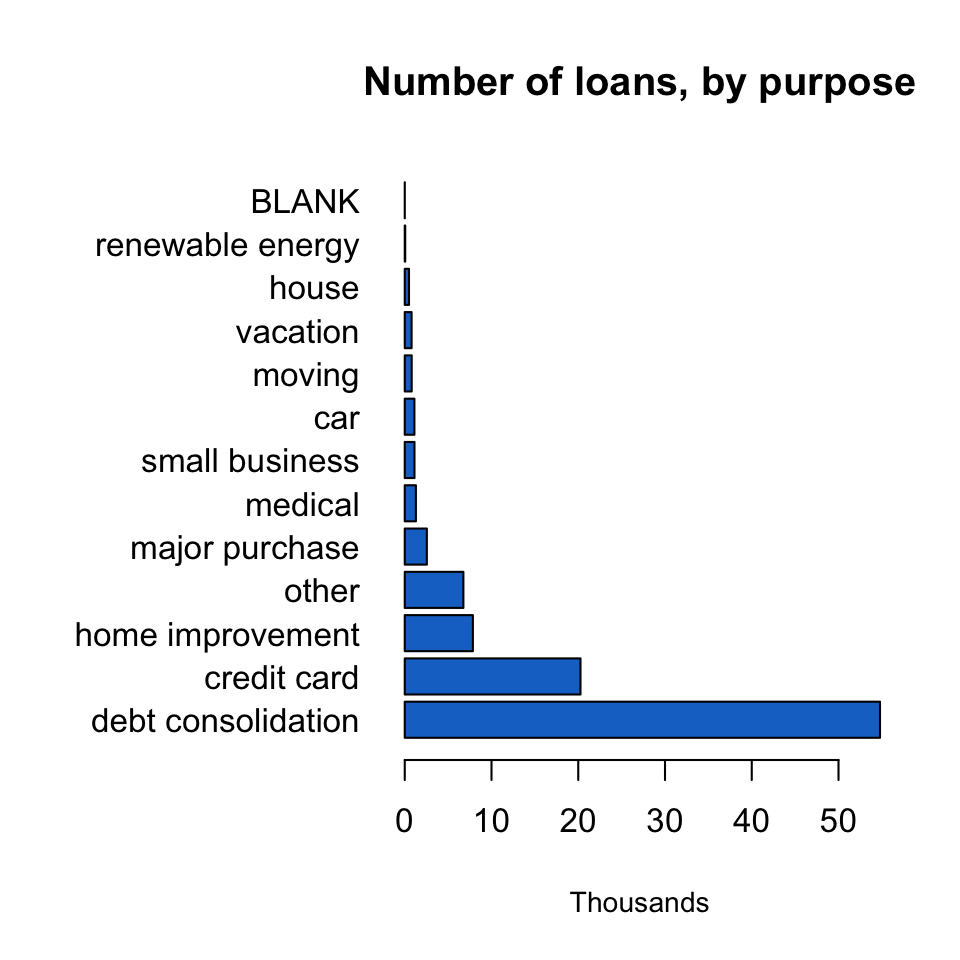

### Loan Grade

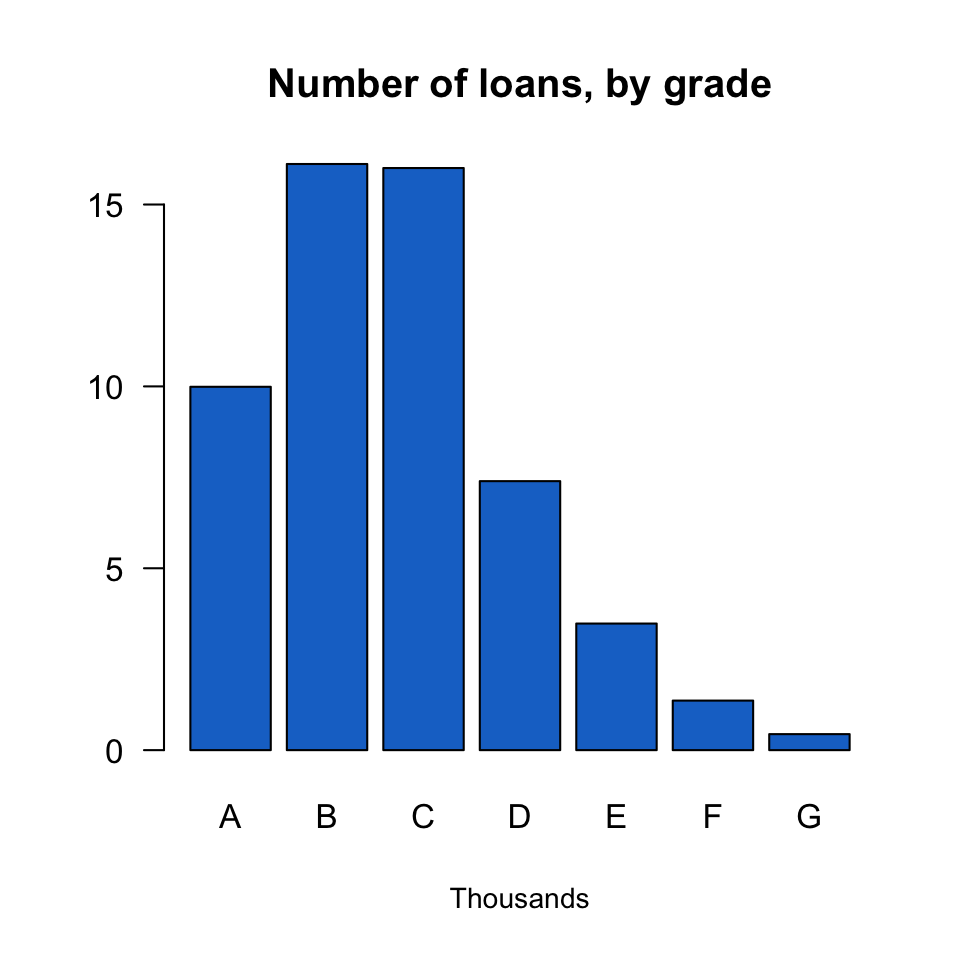

### Loan Amount

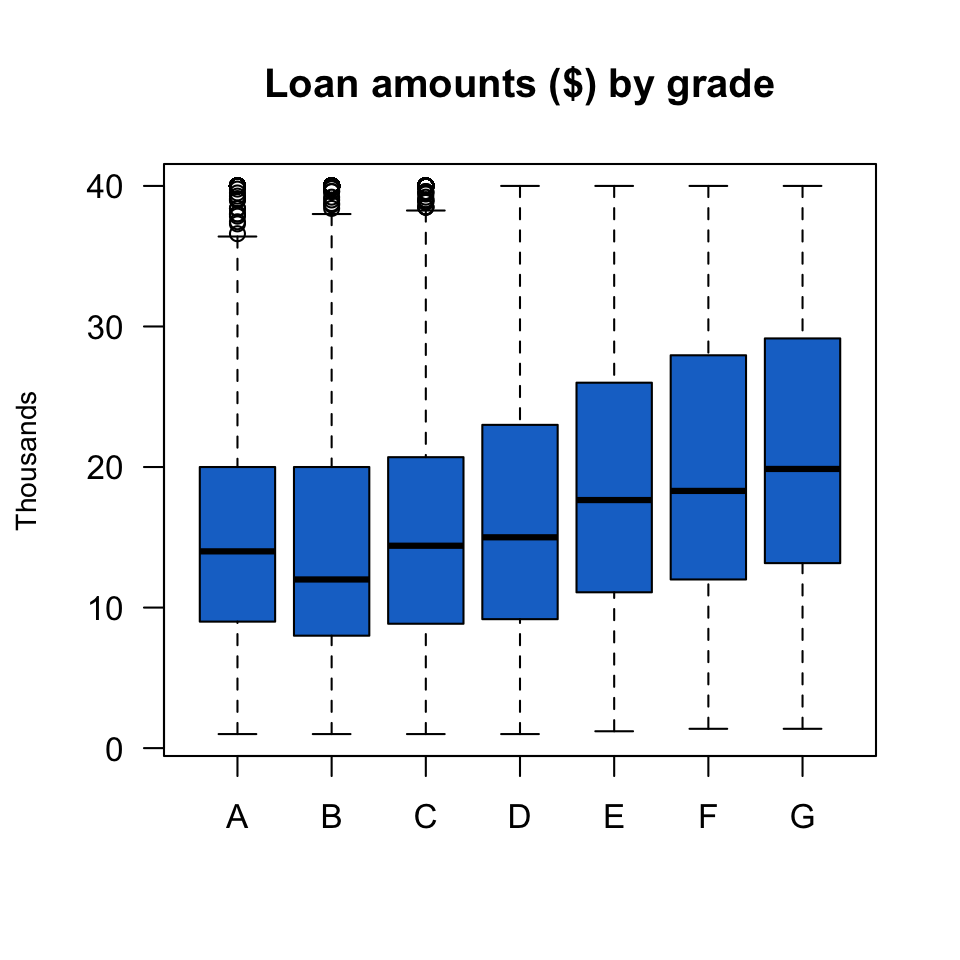

### Interest Rate

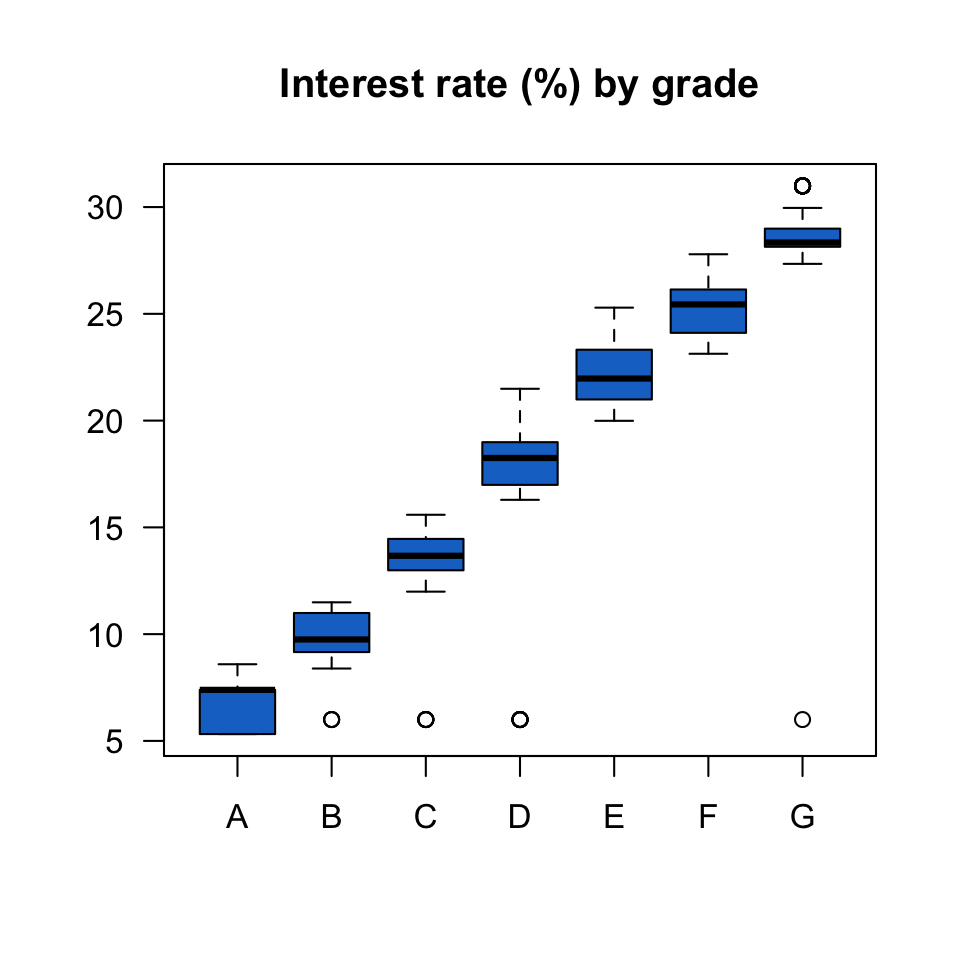

## Modeling

Training, testing, and validation percentages were 60%, 20%, and 20%, respectively. Model details are provided in the tabs below.

### AutoML

We allowed the AutoML model search algorithm to run for 150 seconds, fitting a total of 10 models. Model StackedEnsemble_AllModels_0_AutoML_20181109_144001 had the highest cross-validated AUC (0.68).

|  | model_id | auc | logloss | mean_per_class_error | rmse | mse |
| --- | --- | --- | --- | --- | --- | --- |
| 1 | StackedEnsemble_AllModels_0_AutoML_20181109_144001 | 0.684910309004076 | 0.441150231717354 | 0.36341634975382 | 0.372065755451694 | 0.13843292637984 |
| 2 | StackedEnsemble_BestOfFamily_0_AutoML_20181109_144001 | 0.68469138730991 | 0.441201448706795 | 0.36284270455506 | 0.372084395355381 | 0.13844679726698 |
| 3 | XRT_0_AutoML_20181109_144001 | 0.678954951055778 | 0.524285036047867 | 0.366739030525926 | 0.390511102715388 | 0.152498921343988 |
| 4 | DRF_0_AutoML_20181109_144001 | 0.673852006946034 | 0.54456732524882 | 0.369262788086154 | 0.38937847173242 | 0.151615594248675 |
| 5 | GBM_grid_0_AutoML_20181109_144001_model_0 | 0.67015325865376 | 0.449900467731834 | 0.377570849387601 | 0.374617838537165 | 0.140338524950257 |
| 6 | GBM_grid_0_AutoML_20181109_144001_model_1 | 0.666540758057619 | 0.463330900313388 | 0.378456366431794 | 0.377963084707179 | 0.142856093401366 |
| 7 | DeepLearning_0_AutoML_20181109_144001 | 0.661096133483906 | 0.467358904807451 | 0.37710699229195 | 0.377736295580789 | 0.142684708999097 |
| 8 | GBM_grid_0_AutoML_20181109_144001_model_2 | 0.657906866182582 | 0.484907538086673 | 0.38400817050049 | 0.382429872303863 | 0.146252607230349 |
| 9 | GBM_grid_0_AutoML_20181109_144001_model_3 | 0.651875783078042 | 0.542483406022825 | 0.390146373312855 | 0.391835426363859 | 0.153535001353747 |
| 10 | GBM_grid_0_AutoML_20181109_144001_model_4 | 0.646941441901879 | 0.518058520006504 | 0.391966835647833 | 0.389002125749157 | 0.151322653837363 |

### LIME

The Local Interpretable Model-Agnostic Explanations (LIME) algorithm was used to provide some insight into the variables that contributed to the model predictions of a few selected loan cases.

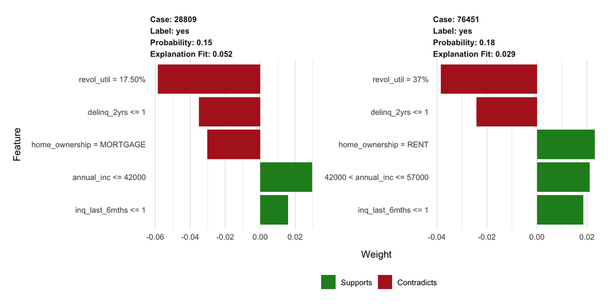

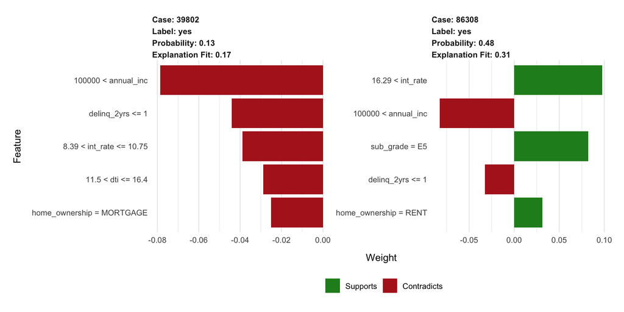

### Variable Importance

|  | variable | relative_importance | scaled_importance | percentage | Description |
| --- | --- | --- | --- | --- | --- |
| 1 | revol_util | 8217.1953125 | 1 | 0.378751338760676 | Revolving line utilization rate, or the amount of credit the borrower is using relative to all available revolving credit. |
| 2 | sub_grade | 4680.03076171875 | 0.569541137059197 | 0.215714468140448 | LC assigned loan subgrade |
| 3 | addr_state | 2370.37719726562 | 0.288465480875185 | 0.109256687067718 | The state provided by the borrower in the loan application |
| 4 | int_rate | 1760.38012695312 | 0.214231262615267 | 0.0811403775199221 | Interest Rate on the loan |
| 5 | grade | 1211.20361328125 | 0.147398664291059 | 0.0558274414317739 | LC assigned loan grade |
| 6 | emp_length | 915.27490234375 | 0.111385316709149 | 0.0421873378218722 | Employment length in years. Possible values are between 0 and 10 where 0 means less than one year and 10 means ten or more years. |
| 7 | dti | 308.872222900391 | 0.0375885215275989 | 0.0142367028506125 | A ratio calculated using the borrower’s total monthly debt payments on the total debt obligations, excluding mortgage and the requested LC loan, divided by the borrower’s self-reported monthly income. |
| 8 | revol_bal | 296.160980224609 | 0.0360416138307056 | 0.013650809489475 | Total credit revolving balance |
| 9 | installment | 288.711578369141 | 0.0351350512418699 | 0.0133074476952832 | The monthly payment owed by the borrower if the loan originates. |
| 10 | loan_amnt | 254.958053588867 | 0.0310273814717565 | 0.011751662270666 | The listed amount of the loan applied for by the borrower. If at some point in time, the credit department reduces the loan amount, then it will be reflected in this value. |

[output cut: 13 more lines]